[O’Hara on GitHub](https://github.com/oharac)

# Eco-Detectives: chapter 9

Compiled on Fri Feb 15 10:03:59 2019 by ohara

```r
knitr::opts_chunk$set(fig.width = 6, fig.height = 4, fig.path = 'Figs/',
                      echo = TRUE, message = FALSE, warning = FALSE)

source('https://raw.githubusercontent.com/oharac/src/master/R/common.R')
```

$\newcommand{\E}{\mathbb{E}} \newcommand{\Var}{\mathrm{Var}}$ $\newcommand{\L}{\mathcal{L}} \newcommand{\LL}{\mathcal{L}}$

# Chapter 9: The Confrontation: Bayesian Goodness of Fit

Modeling animal emergence assuming the number of emergences per unit time (e.g. insects/day) can be modeled as Poisson distribution with rate parameter $r$.

$$\begin{align*}
&\Pr\{data | hypothesis\}\\
&= \Pr\{\text{$k$ emergences in a single period | emergence rate is $r$}\}\\
&= \Pr\{k | r\} = \frac{e^{-r}r^k}{k!}
\end{align*}$$

That last is also an expression of likelihood $\LL\{r|k\} = \Pr\{k|r\}$. To use the data to make statements about the likelihood of different values of the emergence parameter, we start with Bayes’ theorem:

$$\begin{align*}
\Pr\{\text{ rate is $r$ | $k$ emergences }\}
&= \frac{\Pr\{\text{$k$ emergences | rate is $r$}\} \text{Prior}\{r\}} {\Pr\{\text{$k$ emergences}\}}
\end{align*}$$

Then the numerator indicates probability that we observe $k$ emergences and the rate is approximately $r$, i.e.
$$\frac{e^{-r} r^k}{k!} f_{prior}(r)$$
And the denominator is the probability that we observe $k$ emergences, i.e. summed across all possible hypotheses about the value of $r$:

$$\Pr\{ \text{observe } k \text{ emergences}\} = \int_0^{\infty} \frac{e^{-r'} r'^k}{k!} f_{prior}(r') dr'$$

This gets us to equation 9.16.

## Pseudocode 9.1: Posterior density

1. Specify the data ($k$), minimum $r_{min}$ and maximum $r_{max}$ values of $r$, and step $\Delta r$.
2. Use equation 9.21 to compute the denominator in equation 9.16.
   $$\sum_{r' = r_{min}(\Delta r)}^{r_{max}} f_{prior}(r') \frac{e^{-r'} (r')^k}{k!} \Delta r$$
3. Compute the posterior density by cycling over the values of $r$, from $r_{min}$ to $r_{max}$ in steps of $\Delta r$, and using Equation 9.16.
   $$f_{post}(r) = \frac{f_{prior}(r) e^{-r} r^k / k!}{\int_0^{\infty} f_{prior}(r') \frac{e^{-r'} (r')^k}{k!} dr'}$$

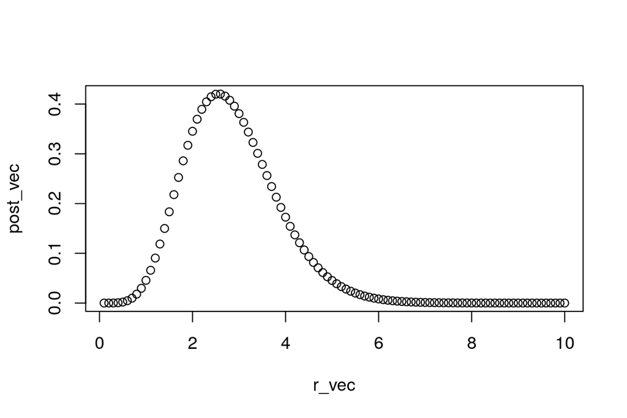

```r
r_true <- 3
k_vec <- rpois(n = 3, lambda = r_true)

dr <- .1
rmin <- dr; rmax = 10
r_vec <- seq(rmin, rmax, dr) ### possible hypotheses for the value of r

### make up a prior distribution for r: say normal around some mean and sd.
### For a given hypothesis of r, return Pr(R < r).
f_prior <- function(r, mean = 4, sd = 2) {
  pnorm(r, mean = mean, sd = sd)
}

### make a function to calculate the likelihood of r given k,
### i.e. prod(exp(-r) * r^k / k!)
### for a single r
likelihood <- function(r, k) {
  df <- data.frame(r1 = rep(r, each = length(k)),
                   k1 = rep(k, times = length(r))) %>%
    mutate(like = exp(-r1) * r1^k1 / factorial(k1),
           like = like / min(sqrt(like))) %>%
             ### this sort of centers the likelihoods to reduce chance of
             ### exponent out of bounds errors.  Since it's a linear transformation,
             ### should divide out in the posterior calculation
    group_by(r1) %>%
    summarize(like = prod(like))
  return(df$like)
}


### compute denominator
denom <- sum(f_prior(r_vec) * likelihood(r_vec, k_vec) * dr)

### compute a vector of numerators, one for each hypothesis
numer_vec <- f_prior(r_vec) * likelihood(r_vec, k_vec)

### compute a vector of probabilities of each r
post_vec <- numer_vec / denom

post_vec_cumulative <- cumsum(post_vec * dr)

plot(post_vec ~ r_vec)
```